```python
import random
import pandas as pd
import matplotlib.pyplot as plt
import numpy as np
from collections import Counter
import re
import requests
from bs4 import BeautifulSoup
import seaborn as sns
```

# Un Juego Simple

- En un casino existe un juego de azar que involucra 2 pasos.
1. Primero, se debe lanzar una moneda.
2. Segundo, se deben sacar dos bolas de dos urnas diferentes (una bola de cada urna).
- Las urnas contienen una distribución de bolas tal como muestra en la siguiente imagen.

[figure not shown]

- El jugador ganará un punto si: obtiene sello y al menos una bola de color azul o si obtiene dos bolas del mismo color. El casino decidió hacer trampa a los jugadores y ha modificado la moneda de tal manera que la probabilidad de obtener cara es 0.4.
- Encuentre a través de simulación el promedio de puntos que el jugador obtendrá, suponiendo que el juego se repite n-veces.
- Visualice una serie de tiempo donde se vea el cambio de los puntos promedio obtenidos por el jugador para valores de $𝑛$ de 10, 100 y 1000
- Calcule los puntos promedio obtenidos por el jugador en 1000 partidas diferentes (cada partida con 1000 repeticiones) y genere un histograma con el número de puntos obtenidos por el jugador
- Interprete los resultados del histograma.

```python
Urna1 = ['Azul', 'Azul', 'Azul', 'Azul', 'Azul', 'Azul', 'Azul', 'Rojo', 'Rojo', 'Rojo']
Urna2 = ['Azul', 'Azul', 'Azul', 'Azul', 'Azul', 'Verde', 'Verde', 'Verde', 'Rojo', 'Rojo']
Moneda = ['Cara', 'Sello']
probabilidades = [0.4, 0.6]
```

## Generador de Juegos

```python
def simulador (probabilidades, iteraciones):

    juego = []

    for i in range (0, iteraciones):

        #Selector de pelotas y moneda
        a = random.randint(0, len(Urna1)-1)
        b = random.randint(0, len(Urna2)-1)
        resultadoMoneda = random.choices(Moneda, weights=probabilidades)[0]

        resultadoUrna1 = Urna1[a]
        resultadoUrna2 = Urna2[b]

        #Validaciones
        if resultadoMoneda == 'Sello' :

            #Validacion de ganador por sello y azul
            if resultadoUrna1 == 'Azul' or resultadoUrna2 == 'Azul':

                resultado = [i, 1]
                juego.append(resultado)
            else:
                resultado = [i, 0]
                juego.append(resultado)

        elif resultadoMoneda == 'Cara' :

            if resultadoUrna1 == resultadoUrna2:

                resultado = [i, 1]
                juego.append(resultado)
            else:
                resultado = [i, 0]
                juego.append(resultado)

    return pd.DataFrame(juego, columns=['Iteracion', 'Resultado'])
```

## Encontrando el promedio con 10, 100 y 1000 partidas

```python
dfPromedio10 = simulador(probabilidades, 10)
dfPromedio100 = simulador(probabilidades, 100)
dfPromedio1000 = simulador(probabilidades, 1000)
```

```python
promedio10 = dfPromedio10['Resultado'].mean()
promedio100 = dfPromedio10['Resultado'].mean()
promedio1000 = dfPromedio10['Resultado'].mean()
print(f'Promedio para 10 simulaciones igual a: {promedio10}')
print(f'Promedio para 100 simulaciones igual a: {promedio100}')
print(f'Promedio para 1000 simulaciones igual a: {promedio1000}')
```

[output not shown]

```python
dfPromedio10.head(10)
```

|  | Iteracion | Resultado |
| --- | --- | --- |
| 0 | 0 | 1 |
| 1 | 1 | 0 |
| 2 | 2 | 1 |
| 3 | 3 | 1 |
| 4 | 4 | 1 |
| 5 | 5 | 0 |
| 6 | 6 | 1 |
| 7 | 7 | 1 |
| 8 | 8 | 1 |
| 9 | 9 | 0 |

```python
promedios10 = []
for i in range(0,10):
    registros = dfPromedio10[0:i+1]
    promedio = registros['Resultado'].mean()
    promedios10.append(promedio)

serieDeTiempoPromedio10 = pd.DataFrame(promedios10, columns=['Promedios'])
serieDeTiempoPromedio10.head(10)
```

|  | Promedios |
| --- | --- |
| 0 | 1.000000 |
| 1 | 0.500000 |
| 2 | 0.666667 |
| 3 | 0.750000 |
| 4 | 0.800000 |
| 5 | 0.666667 |
| 6 | 0.714286 |
| 7 | 0.750000 |
| 8 | 0.777778 |
| 9 | 0.700000 |

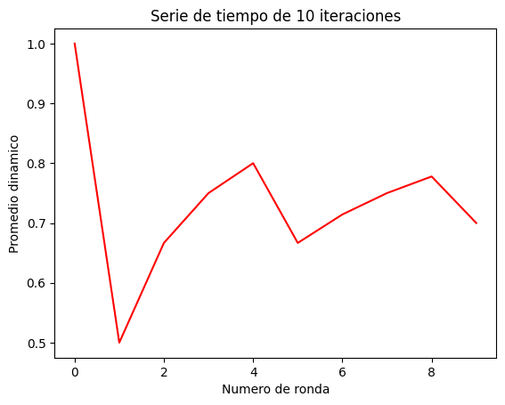

```python
plt.plot(serieDeTiempoPromedio10.index, serieDeTiempoPromedio10['Promedios'], 'red')
plt.xlabel('Numero de ronda')
plt.ylabel('Promedio dinamico')
plt.title('Serie de tiempo de 10 iteraciones')
```

```python
juegos100 = []
for i in range (0, 100):
    registros = dfPromedio100[0: i+1]
    promedios = registros['Resultado'].mean()
    juegos100.append(promedios)

serieDeTiempoPromedio100 = pd.DataFrame(juegos100, columns=['Promedios'])
serieDeTiempoPromedio100.head(10)
```

|  | Promedios |
| --- | --- |
| 0 | 0.000000 |
| 1 | 0.500000 |
| 2 | 0.666667 |
| 3 | 0.750000 |
| 4 | 0.600000 |
| 5 | 0.666667 |
| 6 | 0.571429 |
| 7 | 0.500000 |
| 8 | 0.444444 |
| 9 | 0.500000 |

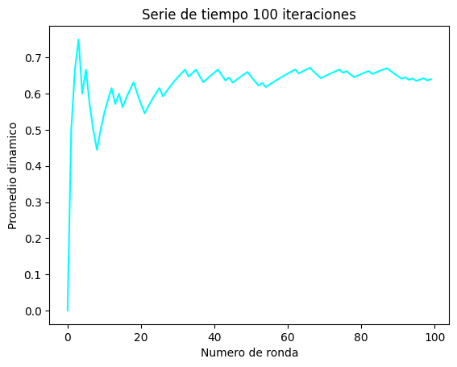

```python
plt.plot(serieDeTiempoPromedio100.index, serieDeTiempoPromedio100['Promedios'], 'Cyan')
plt.xlabel('Numero de ronda')
plt.ylabel('Promedio dinamico')
plt.title('Serie de tiempo 100 iteraciones')
```

```python
juegos1000 = []

for i in range (0, 1000):
    registro = dfPromedio1000[0:i+1]
    promedios = registro['Resultado'].mean()
    juegos1000.append(promedios)

serieDeTiempoPromedio1000 = pd.DataFrame(juegos1000, columns=['Promedios'])
serieDeTiempoPromedio1000.head(10)
```

|  | Promedios |
| --- | --- |
| 0 | 1.000000 |
| 1 | 1.000000 |
| 2 | 1.000000 |
| 3 | 1.000000 |
| 4 | 1.000000 |
| 5 | 0.833333 |
| 6 | 0.857143 |
| 7 | 0.750000 |
| 8 | 0.777778 |
| 9 | 0.700000 |

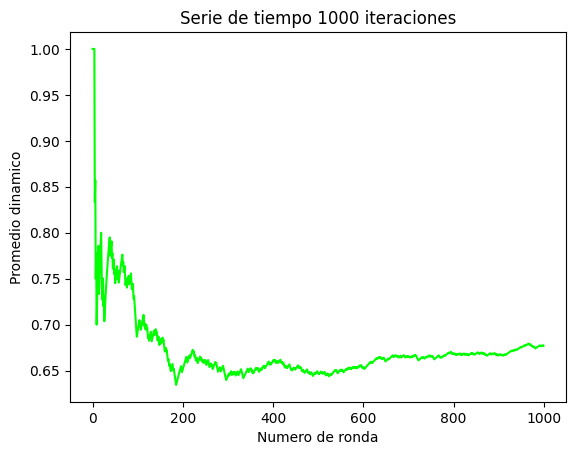

```python
plt.plot(serieDeTiempoPromedio1000.index, serieDeTiempoPromedio1000['Promedios'], 'lime')
plt.xlabel('Numero de ronda')
plt.ylabel('Promedio dinamico')
plt.title('Serie de tiempo 1000 iteraciones')
```